# CH8 : Clustering

## Question 7

Plot the data (Yellow.cards vs Points). Color the points corresponding to their cluster.

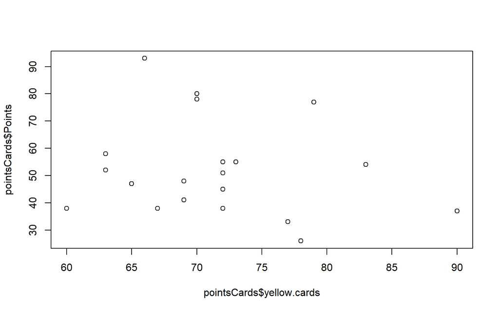

```r
plot(pointsCards$yellow.cards,pointsCards$Points)
```

## Question 8

Add to the previous plot the clusters centroids and add the names of the observations.

```r
# another method
library(factoextra)
```

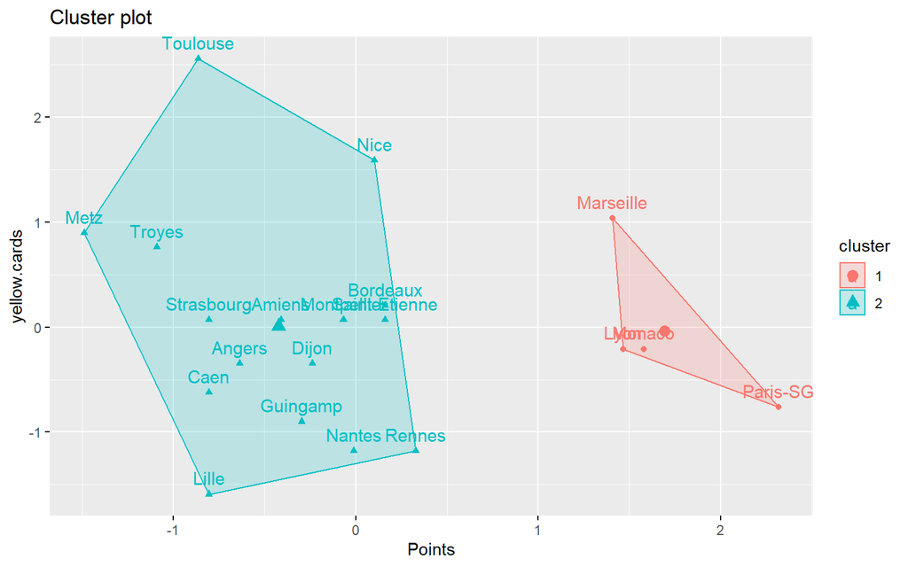

```r
library(cluster)
fviz_cluster(km, data = pointsCards)
```

## Question 9

Re-run k-means on pointsCards using 3 and 4 clusters and store the results into km3 and km4 respectively. Visualize the results like in question 7 and 8.

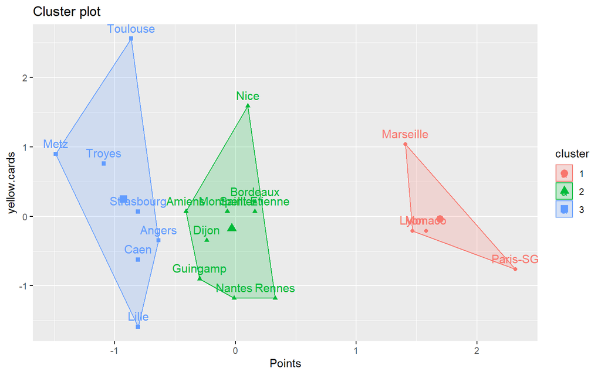

```r
km3=kmeans(pointsCards,centers = 3,nstart = 20)
km4=kmeans(pointsCards,centers = 4,nstart = 20)

fviz_cluster(km3, data = pointsCards)
```

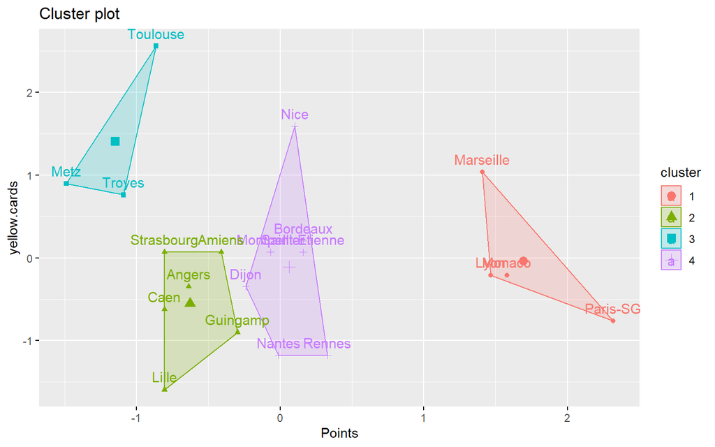

```r
fviz_cluster(km4, data = pointsCards)
```

## Question 10

Use this code to visualize the `within groups sum of squares` of the `k-means` clustering results

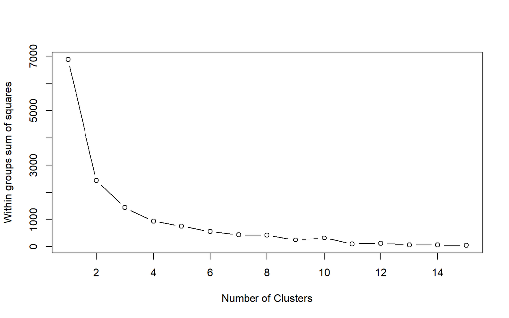

```r
mydata <- pointsCards
wss <- (nrow(mydata)-1)*sum(apply(mydata,2,var))
for (i in 2:15){
    wss[i] <- sum(kmeans(mydata,centers=i)$withinss)
    }

plot(1:15, wss, type="b", xlab="Number of Clusters",
      ylab="Within groups sum of squares")
```

## Question 11

Modify the code of the previous question in order to visualize the `between_SS / total_SS`. Interpret the results.

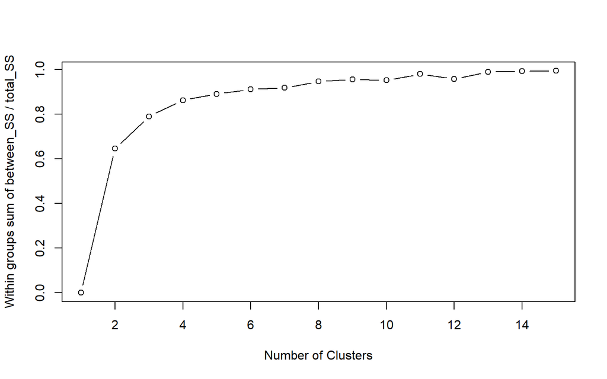

```r
mydata <- pointsCards
#wss <- (nrow(mydata)-1)*sum(apply(mydata,2,var))
for (i in 1:15){
  kkm=kmeans(mydata,centers=i)
    wss[i] <- sum(kkm$betweenss/kkm$totss)
    }

plot(1:15, wss, type="b", xlab="Number of Clusters",
      ylab="Within groups sum of between_SS / total_SS")
```

```r
# SS stands for Sum of Squares, so it's the usual decomposition of deviance in deviance "Between" and deviance "Within"

# the between_SS is approaching to Total_ss ratio when number of cluster increase

# Ideally you want a clustering that has the properties of internal cohesion and external separation, i.e. the BSS/TSS ratio should approach 1.
```

## Question 12

Now we consider all features. Scale the dataset and transform it to a data frame again. Store the scaled dataset into ligue1_scaled.

```r
ligue1_scaled=scale(ligue1)
ligue1_scaled=data.frame(ligue1_scaled)
head(ligue1_scaled)
```

```
##              Points      Wins      Draws      Loses Goals.scored Goals.conceded
## Paris-SG  2.3182291 2.4502435 -1.3224461 -1.8871953    2.6102823     -1.8281435
## Monaco    1.5795777 1.6224585 -0.5877538 -1.3816966    1.5448609     -0.5367397
## Lyon      1.4659390 1.4569015 -0.2204077 -1.3816966    1.6375063     -0.6981652
## Marseille 1.4091196 1.2913445  0.5142846 -1.5501962    1.3132476     -0.3753142
## Rennes    0.3295522 0.2980026  0.1469385 -0.3706991   -0.0764324     -0.6174525
## Bordeaux  0.1590942 0.2980026 -0.9550999  0.1347997    0.0625356     -0.2946015
##           Difference.goals Points.per.game  red.cards yellow.cards
## Paris-SG         2.7121979       2.3164594  0.8720816   -0.7607901
## Monaco           1.3732648       1.5844926 -0.6668859   -0.2074882
## Lyon             1.5105912       1.4553221 -1.1798751   -0.2074882
## Marseille        1.1329434       1.4122652 -0.6668859    1.0374411
## Rennes           0.2059897       0.3358436  0.3590924   -1.1757666
## Bordeaux         0.1716581       0.1636161 -1.1798751    0.2074882
##           clean.sheets.percentage failed.to.score.percentage
## Paris-SG                1.8731961                 -1.5205232
## Monaco                  0.9125827                 -1.2871948
## Lyon                    1.1047054                 -1.2871948
## Marseille               0.9125827                 -1.5205232
## Rennes                 -0.1440920                 -1.1316426
## Bordeaux               -0.1440920                  0.7349844
##           shots.per.match.average shots.on.goal.per.match.average
## Paris-SG                2.3000011                       2.8272166
## Monaco                  2.0924906                      -1.1174791
## Lyon                    1.4587425                       2.0958966
## Marseille               0.4716657                      -0.5856100
## Rennes                  0.2921972                      -0.1202246
## Bordeaux                0.2192881                       0.6110954
##           ball.possession.per.game.average sum.offside.in.attack
## Paris-SG                         2.5183827             1.8732319
## Monaco                           1.4509837             1.4503804
## Lyon                             1.2039355             1.1120993
## Marseille                        1.1134141             0.9429587
## Rennes                           0.4910790             0.8583884
## Bordeaux                         0.3345523             0.6892478
##           sum.offside.in.defense corners.per.game.average fouls.for.sum
## Paris-SG             0.869044021                2.4711733     2.9055311
## Monaco               0.531186734                2.0356044     0.9604057
## Lyon                 0.005630955                1.1508549     0.8793588
## Marseille           -0.294686634                0.6063937     0.7172650
## Rennes              -0.707623317                0.5791706     0.5551712
## Bordeaux            -1.383337891                0.3205515     0.4741243
##           fouls.against.sum
## Paris-SG          0.1251992
## Monaco            0.5864596
## Lyon              0.2569879
## Marseille        -1.1926874
## Rennes            0.9159312
## Bordeaux          0.3887766
```

## Question 13

Apply `kmeans()` on ligue1 and on ligue1_scaled using 3 clusters and 20 iterations. Store the results into km.ligue1 and km.ligue1.scaled respectively (do not forget to set a seed)

```r
set.seed(123)
km.ligue1=kmeans(ligue1,centers = 3,nstart = 20)

km.ligue1_scaled=kmeans(ligue1_scaled,centers = 3,nstart = 20)
```

## Question 14

How many observations there are in each cluster of km.ligue1 and km.ligue1.scaled ? (you can use `table()`). Do you obtain the same results when you perform `kmeans()` on the scaled and unscaled data?

```r
table(km.ligue1$cluster)
```

```
##
## 1 2 3
## 8 8 4
```

```r
table(km.ligue1_scaled$cluster)
```

```
##
## 1 2 3
## 8 8 4
```

```r
# 8 8 4 observations for the cluster umber 1,2,3
# yes we obtain the same results for the scaled data
```

## Question 15

Now we try to combine clustering with `PCA` to plot our high dimensionnal clustering. Apply `PCA` on ligue1 dataset and store you results in pcaligue1. Do we need to apply `PCA` on the scaled dataset? Justify your answer.

```r
library(FactoMineR) # for PCA
pcaligue1=PCA(ligue1)
```

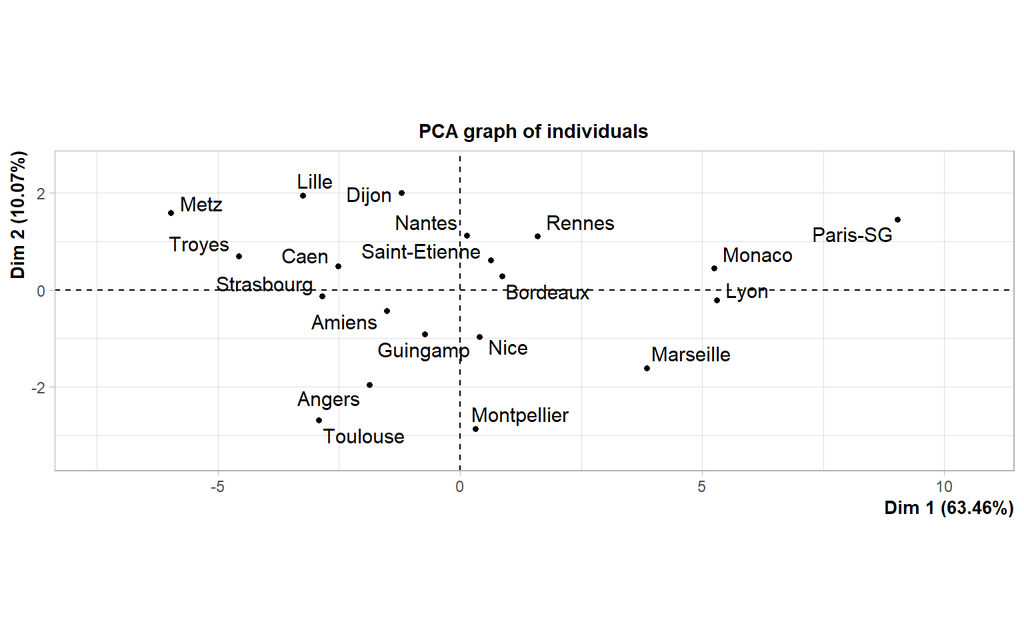

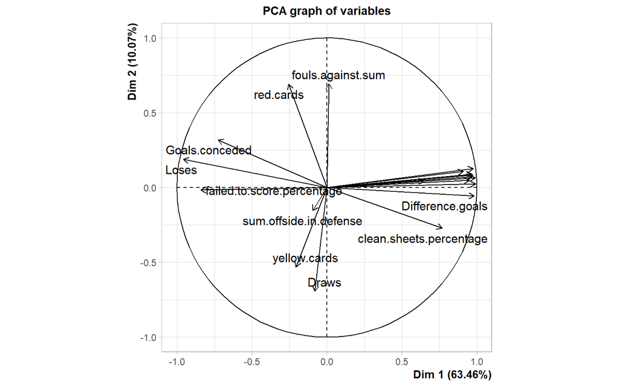

```r
# we don't need to apply PCA on the scaled dataset, beacause the transformation is uniform?
```

## Question 16

Plot the observations and the variables on the first two principal components (biplot). Interpret the results.

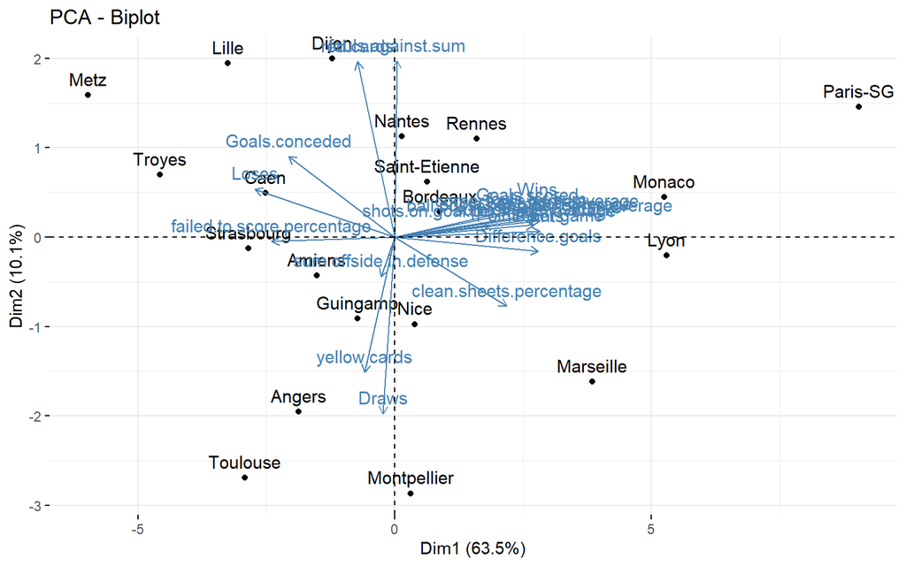

```r
fviz_pca_biplot(pcaligue1)
```

```r
# interpretation ?
```

## Question 17

Visualize the teams on the first two principal components and color them with respect to their cluster

```r
var = get_pca_var(pcaligue1)
```

## Question 18

Recall that the figure of question 17 is a visualization with `PC1` and `PC2` of the clustering done with all the variables, not on `PC1` and `PC2`. Now apply the `kmeans()` clustering taking only the first two `PCs` instead the variables of original dataset. Visualize the results and compare with the question 17.

# Hierarchical Clustering

## Question 1

We will perform hierarchical clustering on customer data, which involves segmenting customers into different groups. Load the file `customer.csv` and name the data : `customer_data`

```r
customer_data <- read.csv("C:/Users/Papa/Documents/customer.csv")
```

## Question 2

Show its summary and structure

```r
summary(customer_data)
```

```
##        ID          Visit.Time   Average.Expense      Sex
##  Min.   : 1.00   Min.   : 1.0   Min.   : 4.50   Min.   :0.0000
##  1st Qu.:15.75   1st Qu.: 5.0   1st Qu.:10.82   1st Qu.:0.0000
##  Median :30.50   Median : 7.5   Median :16.00   Median :1.0000
##  Mean   :30.50   Mean   : 8.4   Mean   :17.06   Mean   :0.6833
##  3rd Qu.:45.25   3rd Qu.:12.0   3rd Qu.:24.90   3rd Qu.:1.0000
##  Max.   :60.00   Max.   :18.0   Max.   :33.70   Max.   :1.0000
##       Age
##  Min.   : 8.00
##  1st Qu.:15.00
##  Median :20.50
##  Mean   :21.43
##  3rd Qu.:27.00
##  Max.   :47.00
```

```r
str(customer_data)
```

```
## 'data.frame':    60 obs. of  5 variables:
##  $ ID             : int  1 2 3 4 5 6 7 8 9 10 ...
##  $ Visit.Time     : int  3 5 16 5 16 3 12 14 6 3 ...
##  $ Average.Expense: num  5.7 14.5 33.5 15.9 24.9 12 28.5 18.8 23.8 5.3 ...
##  $ Sex            : int  0 0 0 0 0 0 0 0 0 0 ...
##  $ Age            : int  10 27 32 30 23 15 33 27 16 11 ...
```

## Question 3

Chek that there is no missing data and then normalize the customer data into the same scale

```r
sapply(customer_data, function(x) sum(is.na(x)))
```

```
##              ID      Visit.Time Average.Expense             Sex             Age
##               0               0               0               0               0
```

```r
customer_data_scaled=scale(customer_data)
```

Before applying any clustering algorithm to a unknown structure data, the first thing to do is to assess the clustering tendency. That is, whether the data contains any inherent grouping structure.

If yes, then how many clusters are there. Next, you can perform hierarchical clustering or partitioning clustering (with a pre-specified number of clusters). Finally, evaluate the goodness of the clustering results.

To assess the clustering tendency, the Hopkins’ statistic and a visual approach can be used. This can be performed using the function `get_clust_tendency()` from the `factoextra` package, which creates an ordered dissimilarity image (ODI): If the value of Hopkins statistic is close to 1 (far above 0.5), then we can conclude that the dataset is significantly clusterable.Moreover, the visual approach detects the clustering tendency by counting the number of square shaped dark (or colored) blocks along the diagonal in the ordered dissimilarity image

## Question 4

Compute the Hopkins statistic and evaluate the cluster structure

```r
get_clust_tendency(customer_data_scaled,n=5)
```

```
## $hopkins_stat
## [1] 0.7405208
##
## $plot
```

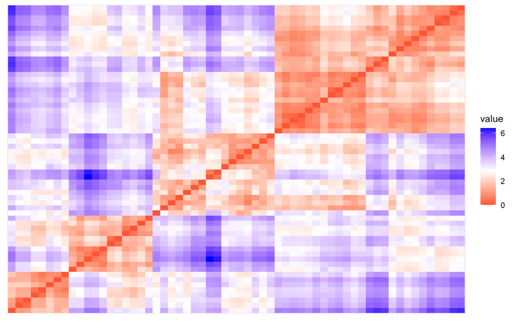

Now we have a first estimation of the number of clusters :4, lets go deeply to answer his question. In fact, there are different methods for determining the optimal number of clusters: `NbClust` R package, provides 30 indices for determining the best number of clustersusing the function `NbClust` by fixing the following imputs:

- `data`: matrix
- `diss`: dissimilarity matrix to be used. By default, `diss=NULL`, but if it is replaced by a dissimilarity matrix, distance should be `NULL`.
- `distance`: the distance measure to be used to compute the dissimilarity matrix. Possible values include `euclidean`, `manhattan` or `NULL`.
- `min.nc`, `max.nc`: minimal and maximal number of clusters, respectively.
- `method`: The cluster analysis method to be used including `ward.D`, `ward.D2`, `single`, `complete`, `average`, `means` and more.

To compute `NbClust()` for kmeans, use `method = "kmeans"`. To compute `NbClust()` for hierarchical clustering, method should be one of c(`ward.D`, `ward.D2`, `single`, `complete`, `average`)

## Question 5

Estimate the optimal number of cluster for the customer data using `NbClust` function

```r
library(NbClust)
NbClust(data=customer_data_scaled,
        min.nc=2, max.nc=20,
        distance = "euclidean",
        method="single")
```

[output not shown]

[output cut: 210 more lines]

[output not shown]

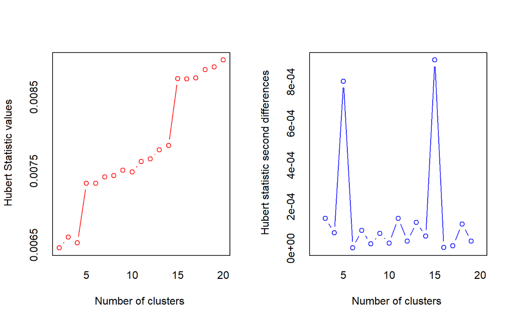

```
## *** : The Hubert index is a graphical method of determining the number of clusters.
##                 In the plot of Hubert index, we seek a significant knee that corresponds to a
##                 significant increase of the value of the measure i.e the significant peak in Hubert
##                 index second differences plot.
##
```

```
## *** : The D index is a graphical method of determining the number of clusters.
##                 In the plot of D index, we seek a significant knee (the significant peak in Dindex
##                 second differences plot) that corresponds to a significant increase of the value of
##                 the measure.
##
```

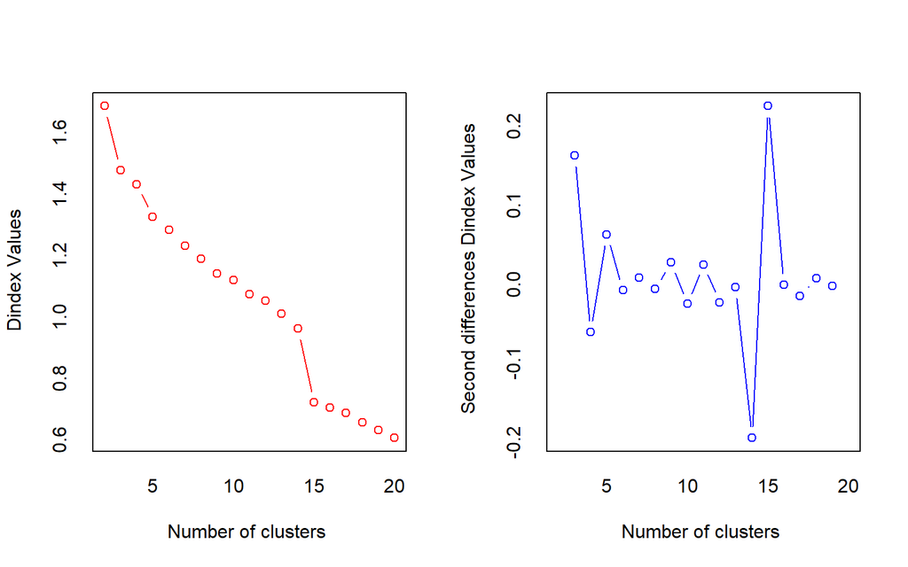

```
## * Among all indices:
## * 2 proposed 2 as the best number of clusters
## * 2 proposed 15 as the best number of clusters
##
##                    ***** Conclusion *****
##
## * According to the majority rule, the best number of clusters is  2
##
##
```

```
## $All.index
##          KL      CH Hartigan      CCC Scott Marriot    TrCovW   TraceW
## 2    3.2570 28.9188  13.1787  -1.2206   NaN       0 2162.3837 196.8504
## 3    0.4739 23.9147   1.5771  -4.0855   NaN       0 1350.8601 160.4036
## 4    1.5819 16.6133   8.6634  -7.2022   NaN       0 1263.7670 156.0850
## 5    1.8176 16.2578   2.3895  -6.7585   NaN       0 1044.2374 135.1732
## 6   19.3109 13.7938   3.3455  -7.5393   NaN       0  954.7892 129.5450
## 7    0.0716 12.5282   1.7242  -7.9051   NaN       0  822.3232 121.9874
## 8    1.4808 11.1202   3.2991  -8.5136   NaN       0  775.2665 118.1438
## 9    0.5225 10.5530   0.7586  -8.6752   NaN       0  667.4649 111.0954
## 10   1.0358  9.4159   3.3336  -9.3412   NaN       0  660.6010 109.4672
## 11   1.0087  9.1853   0.4237  -9.3743   NaN       0  608.1826 102.6249
## 12   0.8699  8.2883   3.0798 -10.0227   NaN       0  597.8522 101.7451
## 13   1.7097  8.1680   2.2973 -11.5866   NaN       0  551.6284  95.6105
## 14   0.0374  7.9129  46.3354 -11.7740   NaN       0  513.8527  91.1550
```

[output cut: 106 more lines]

## Question 6

Use agglomerative hierarchical clustering to cluster the customer data

```r
library("cluster")
# Agglomerative Nesting (Hierarchical Clustering)
res.agnes <- agnes(x = customer_data_scaled, # data matrix
                   stand = TRUE, # Standardize the data
                   metric = "euclidean", # metric for distance matrix
                   method = "ward" # Linkage method
                   )
```

## Question 7

Plot the dendogram by specifying hang to display labels at the bottom of the dendrogram, and cex to shrink the label to 70 percent of the normal size

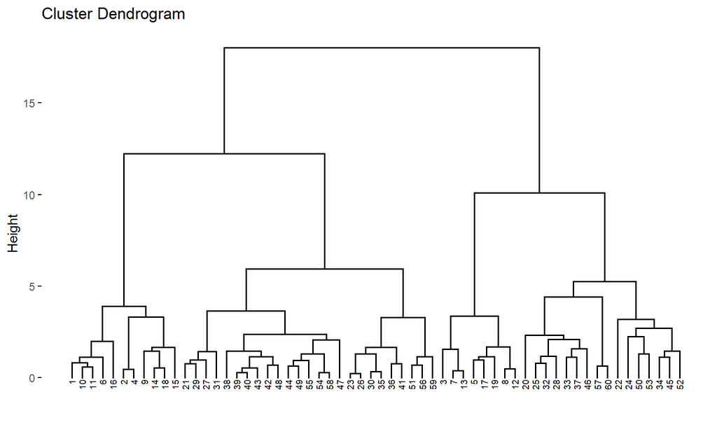

```r
# cex: label size
library("factoextra")
fviz_dend(res.agnes, cex = 0.5)
```

In a dendrogram, we can see the hierarchy of clusters, but we have not grouped data into different clusters yet. However, we can determine how many clusters are within the dendrogram and cut the dendrogram at a certain tree height to separate the data into different groups. We will use the cutree function to separate the data into a given number of clusters.

## Question 8

Cut trees into clusters and show cluster labels for the data.

```r
# Cut tree into 4 groups
grp <- cutree(res.agnes, k = 4)
head(grp, n = 6)
```

```
## [1] 1 1 2 1 2 1
```

## Question 9

Show the count of data within each cluster using the function `table`

```r
table(grp)
```

```
## grp
##  1  2  3  4
## 11  8 16 25
```

## Question 10

Visualize the clustered data with red rectangle border

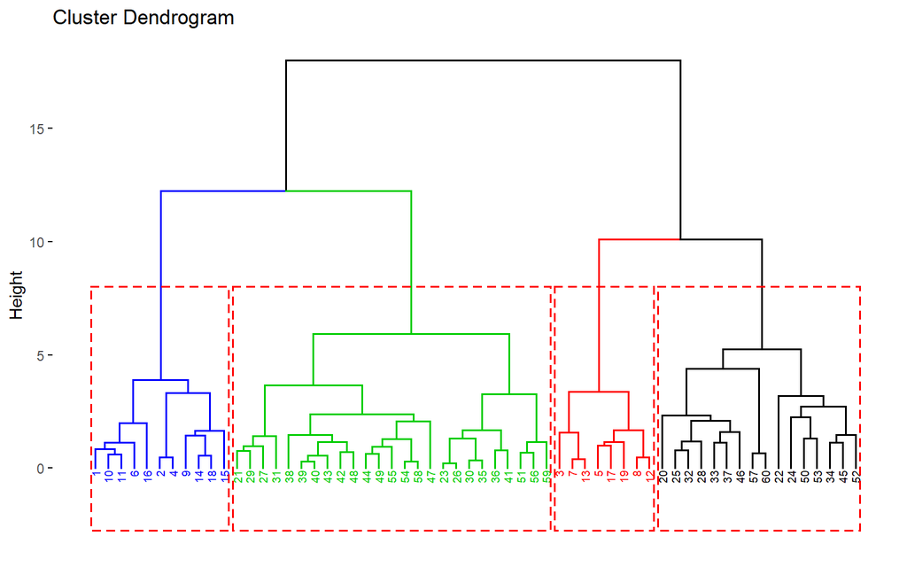

```r
fviz_dend(res.agnes,
          cex = 0.5, k = 4,
          rect = TRUE,rect_border="red",
           k_colors =c("blue", "green3", "red", "black"))
```

## Question 11

Hilight the cluster 2 with red rectangle border

## Question 12

Using the function `fviz_cluster()` [in `factoextra`], visualize the result in a scatter plot: Observations are represented by points in the plot, using principal components. A frame is drawn around each cluster

```r
#res.agnes2= hclust(dist(customer_data_scaled),method="complete")
#fviz_cluster(res.agnes)
```

Next, we’ll use the package `dendextend` which contains many functions for comparing two dendrograms.

## Question 13

Compute two hierarchical clusterings using ‘complete’ and ‘centroid’ linkage. Compute two dendograms and use the function `tanglegram()` to plot the two dendrograms, side by side, with their labels connected by lines. This method can be used for visually comparing two methods of Hierarchical clustering

```r
library(dendextend)
```

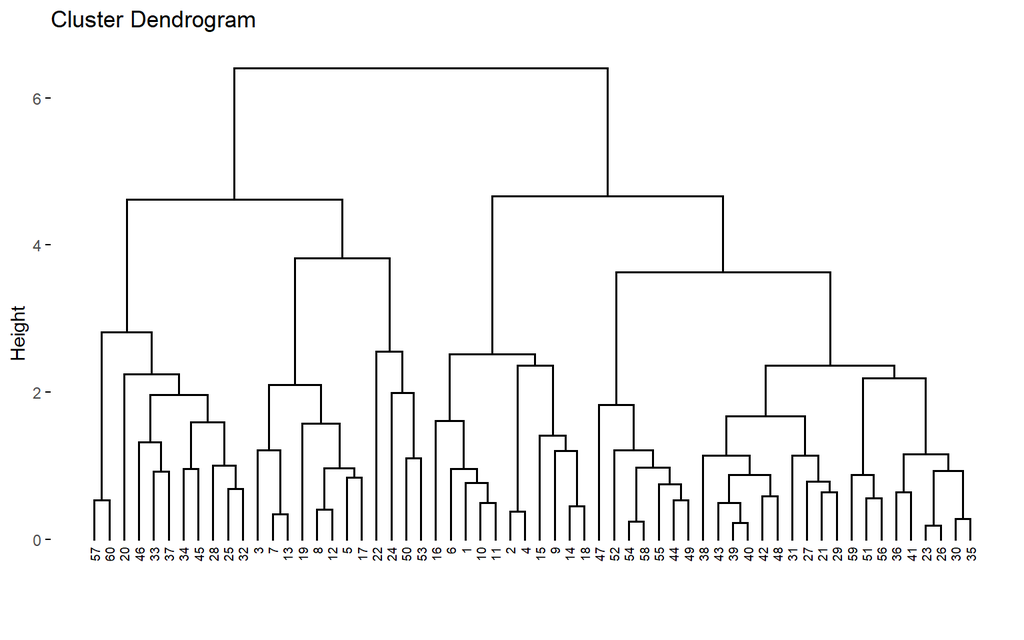

```r
hierarchical1=hclust(dist(customer_data_scaled),method="complete")
hierarchical2=hclust(dist(customer_data_scaled),method="centroid")


fviz_dend(hierarchical1, cex = 0.5)
```

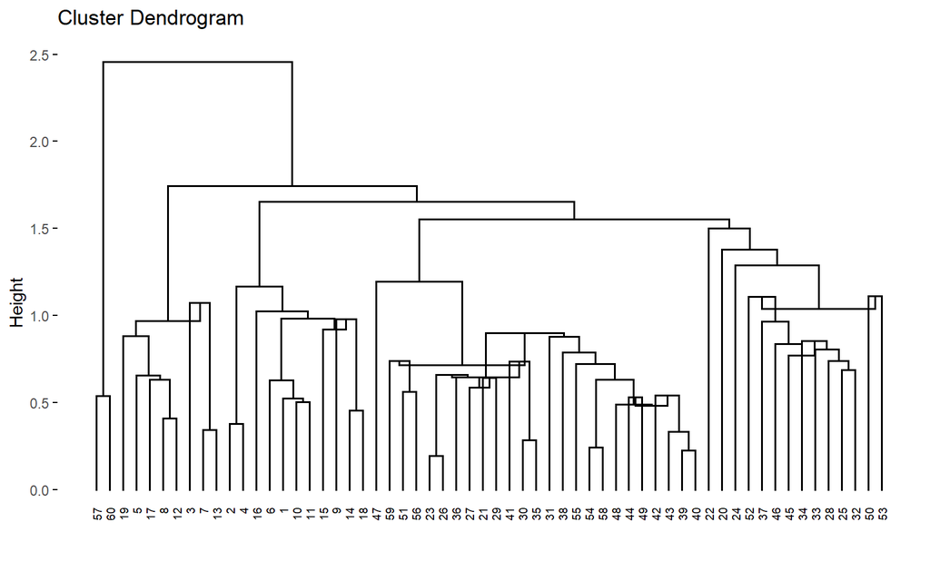

```r
fviz_dend(hierarchical2, cex = 0.5)
```

## Question 14

The quality of the alignment of the two trees can be measured using the function `entanglement()` (a 1 score is the best possible value).

```r
entanglement(hierarchical1,hierarchical2)
```

```
## [1] 0.5536779
```

A simple way to compare many dendogram is a correlation matrix between a list of dendrogram

## Question 15

Compare simultaneously multiple dendrograms using the chaining operator `%>%` (available in `dendextend`) which is used to run multiple function at the same time.

```r
library(dendextend)
```

Alternatively, we can use the agnes function from the `cluster` packages. This functions behave very similarly; however, it can also get the agglomerative coefficient, which measures the amount of clustering structure found (values closer to 1 suggest strong clustering structure).

## Question 16

Find which hierarchical clustering methods can identify stronger clustering structures among the following linkages : `average`, `single`, `complete`, `ward`.